# S&P 500 Classification

Fred Viole

27 July, 2023

# Intro

We are going to define a function for comparing a time-series for its most representative counterpart in a reference time-series(s). This expands the analysis already presented in [“Time-Series Classificataion”](https://htmlpreview.github.io/?https://github.com/OVVO-Financial/LegacyNNS/blob/LegacyNNS-Beta-Version/examples/Time_Series_Classification.html) by using vectors of different lengths for partial time-series matching.

# Load Required Packages in R

```r
#require(devtools); install_github('OVVO-Financial/LegacyNNS', ref = "LegacyNNS-Beta-Version")
require(LegacyNNS)
require(data.table)
require(quantmod)
require(zoo)
```

# Get data

We will load the data for the `S&P 500` index from 1950. This will create the variable `GSPC`. Further, we will create:

1. A daily return based dataset: `current_returns` & `reference_returns`
2. A dataset of closing prices: `current` & `reference`
3. A window length: `w`

```r
# Download data
getSymbols('^GSPC', src='yahoo', from=as.Date("1950-01-01"))
```

```
## [1] "GSPC"
```

```r
# Create reference distribution
reference_returns <- dailyReturn(GSPC)
reference <- GSPC$GSPC.Adjusted

# Create current distribution (or sub in another period)
current_year <- year(Sys.Date())
current_returns <- reference_returns[as.character(current_year)]
current <- reference[as.character(current_year)]

# Window length
w <- length(current_returns)
```

# Which Calendar Year is Most Similar?

Let’s identify the calendar year which is most similar. We will create a series of `reference` distributions from the beginning of each calendar year of **equal length** to the `current` distribution. This just uses `LegacyNNS.reg(..., order = "max")` which is a knn surrogate, and `k=1` in this classification instance.

```r
returns_list <- list()
last_year <- current_year - 1

for(i in seq(1950,last_year,1)){
    index <- which(i == seq(1950,last_year,1))
    returns_list[[index]] <- reference_returns[eval(as.character(i))][1:w]
}

IV <- matrix(unlist(returns_list), ncol = w, byrow = TRUE)
DV <- seq(1950,last_year,1)

LegacyNNS.estimate <- LegacyNNS.reg(IV, DV, point.est = as.numeric(current_returns), order = 'max', n.best = 1, dist = "L2",
                        residual.plot = FALSE, type = "CLASS")$Point.est
LegacyNNS.estimate
```

```
## [1] 1971
```

```r
# View the plot on both series
plot(as.zoo(reference[as.character(LegacyNNS.estimate)][1:w]), col = c("blue"), xlab = "Date", ylab = "Price",
     main = paste("LegacyNNS \n Most Similar Calendar Year \n", LegacyNNS.estimate))
par(new =TRUE)
plot(as.zoo(current),screens = 1,lwd = 3, col = "red",xlab = "",ylab = "", xaxt = "n", yaxt = "n")
axis(4)
mtext("Price", side = 4, line = 3)
legend("topleft",c("Reference","Current (RHS)"),lty = c(1,1),col = c("blue","red"),cex = 0.5, bty = "n")
```

[figure not shown]

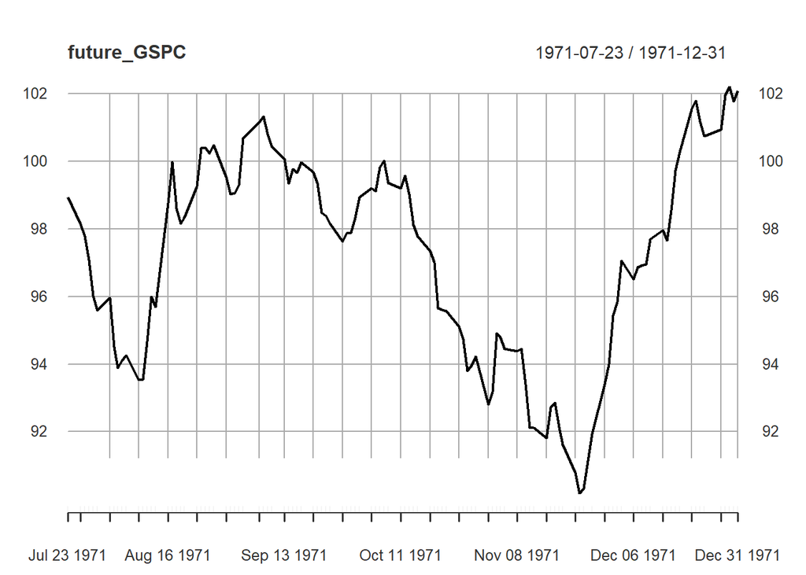

```r
# Future from most similar period
future_GSPC <- reference[as.character(LegacyNNS.estimate)][w:min((2*w),length(reference[as.character(LegacyNNS.estimate)]))]
plot(future_GSPC)
```

# Finding the Most Similar Period (Non-Calendar Year)

Next we will eschew the calendar year and scan overlapping years to find the most similar period. The independent variable matrices get excessive (since each observation is an IV and they sequentially overlap), so we can simplify by minimizing the sum-of-squared differences, or maximizing the linear correlation of vectors to determine similarity.

## Remove current period, also a verification of similarity!

```r
custom_cor <- function(x,y){
  a <- cor(as.numeric(x), as.numeric(y))
  return(a)
}

# Remove current period (look what we get if we don't!!!)
best.period.1 <- which.max( rollapply( seq_along(reference_returns), width = w, function(i)  custom_cor(reference_returns[i], current_returns) ) )

GSPC[best.period.1]
```

```
##            GSPC.Open GSPC.High GSPC.Low GSPC.Close GSPC.Volume GSPC.Adjusted
## 2023-01-03   3853.29   3878.46  3794.33    3824.14  3959140000       3824.14
```

Yup, exact match! Let’s remove those `current` observations from the `reference`.

```r
reference <- head(reference, length(reference)-w)
reference_returns <- head(reference_returns, length(reference_returns)-w)
```

## Method 1: Linear Correlation and Normalized Returns Data

The first method we will use is a regular linear correlation of the daily returns data.

```r
best.period.1 <- which.max( rollapply( seq_along(reference_returns), width = w, function(i)  custom_cor(reference_returns[i], current_returns) ) )

# Most smilar period
GSPC[c(best.period.1, best.period.1+w)]
```

```
##            GSPC.Open GSPC.High GSPC.Low GSPC.Close GSPC.Volume GSPC.Adjusted
## 1974-10-02         0     64.62    62.74      63.38    12230000         63.38
## 1975-04-24         0     86.92    85.00      86.04    19050000         86.04
```

```r
# View Plot on Both Series
plot(as.zoo(reference[best.period.1:(best.period.1+w)]), col = c("blue"), xlab = "Date", ylab = "Price",
     main = paste("LINEAR CORRELATION \n Most Similar Period \n", index(reference_returns[best.period.1]), " : ", index(reference_returns[(best.period.1+w)])))
par(new =TRUE)
plot(as.zoo(current),screens = 1,lwd = 3, col = "red", xlab = "", ylab = "", xaxt = "n", yaxt = "n")
axis(4)
mtext("Price", side = 4, line = 3)
legend("topleft",c("Reference","Current (RHS)"), lty = c(1,1), col = c("blue","red"), cex = 0.5, bty = "n")
```

[figure not shown]

```r
# Future from most similar period
GSPC[c(best.period.1+w,best.period.1+(2*w))]
```

```
##            GSPC.Open GSPC.High GSPC.Low GSPC.Close GSPC.Volume GSPC.Adjusted
## 1975-04-24         0     86.92     85.0      86.04    19050000         86.04
## 1975-11-12         0     91.63     89.8      91.19    23960000         91.19
```

```r
future_GSPC_1 <- reference[(best.period.1+w):(best.period.1+(2*w))]
plot(future_GSPC_1)
```

[figure not shown]

```r
# SSE
sum( (as.numeric(reference_returns[best.period.1:(best.period.1-1+w)]) - as.numeric(current_returns))^2 )
```

```
## [1] 0.02554008
```

## Method 2: Sum-of-Squared Differences of Daily Returns

The second method again uses the daily returns, but will sum their squared differences.

### Accuracy Check

```r
reference_returns <- dailyReturn(GSPC)

best.period.2 <- which.min(rollapply(seq_along(reference_returns), width = w, function(i)  sum( (as.numeric(reference_returns[i])-as.numeric(current_returns))^2 ) ) )


# Most smilar period
GSPC[best.period.2]
```

```
##            GSPC.Open GSPC.High GSPC.Low GSPC.Close GSPC.Volume GSPC.Adjusted
## 2023-01-03   3853.29   3878.46  3794.33    3824.14  3959140000       3824.14
```

Yup, it works!

### Apply Sum-of-Squared Differences to Daily Returns

Now we will apply the sum-of-squared differences to the daily returns data, after removing the `current` observations from the `reference`…again.

```r
reference_returns <- head(reference_returns, length(reference_returns)-w)

best.period.2 <- which.min( rollapply( seq_along(reference_returns), width = w, function(i)  sum( (as.numeric(reference_returns[i])-as.numeric(current_returns))^2 ) ) )


# Most similar period
GSPC[c(best.period.2, best.period.2+w)]
```

```
##            GSPC.Open GSPC.High GSPC.Low GSPC.Close GSPC.Volume GSPC.Adjusted
## 1964-04-01         0     79.58    78.67      79.24     5510000         79.24
## 1964-10-20         0     85.57    84.56      85.18     5140000         85.18
```

```r
# View Plot on Both Series
plot(as.zoo(reference[best.period.2:(best.period.2+w)]),lty = 1, col = c("blue"), xlab = "Date", ylab = "Price",
     main = paste("SUM OF SQUARED DIFFERENCES \n Most Similar Period \n", index(reference_returns[best.period.2]), " : ", index(reference_returns[(best.period.2+w)])))
par(new =TRUE)
plot(as.zoo(current), screens = 1, lwd = 3, col = "red", xlab = "", ylab = "", xaxt = "n", yaxt = "n")
axis(4)
mtext("Price", side = 4, line = 3)
legend("topleft", c("Reference","Current"), lty = c(1,1), col = c("blue","red"), cex = 0.5, bty = "n")
```

[figure not shown]

```r
# Future from most similar period
GSPC[c(best.period.2+w, best.period.2+(2*w))]
```

```
##            GSPC.Open GSPC.High GSPC.Low GSPC.Close GSPC.Volume GSPC.Adjusted
## 1964-10-20         0     85.57    84.56      85.18     5140000         85.18
## 1965-05-13         0     90.68    89.68      90.27     6460000         90.27
```

```r
future_GSPC_2 <- reference[(best.period.2+w):(best.period.2+(2*w))]
plot(future_GSPC_2)
```

[figure not shown]

```r
# SSE
sum( (as.numeric(reference_returns[best.period.2:(best.period.2-1+w)]) - as.numeric(current_returns))^2 )
```

```
## [1] 0.01046234
```

# Comments

- Evaluating each of the methods most similar daily returns via the minimum sum-of-squared errors, reveals Method #2 has the best fit.
- We have not ventured far into the definition of $similar$. We have demonstrated 2 methods of determining similarity, and unfortunately, the future outcomes are substantially varied based on the definition and evaluation criteria.
- Based on prevailing evaluation criteria, both future outcomes are significantly positive from current levels for the next 141 day period

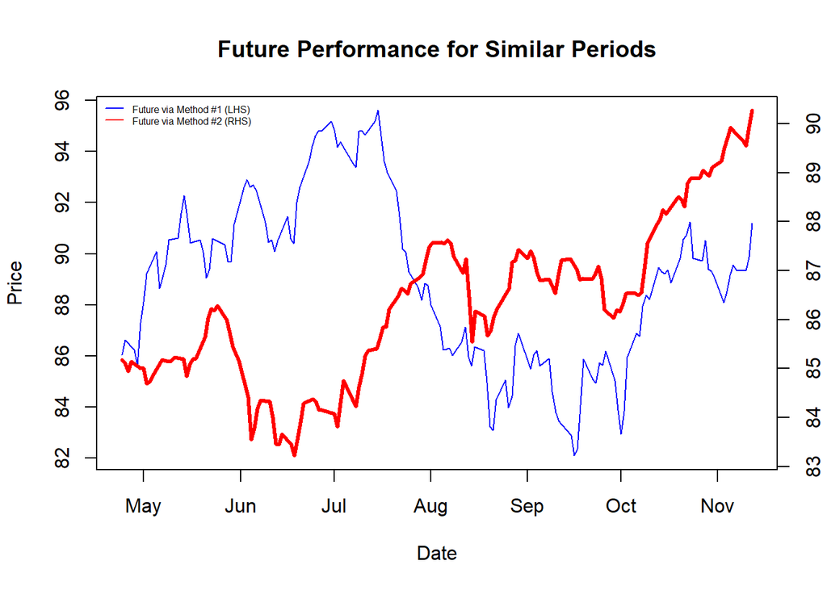

```r
# View Plot on Both Series
plot(as.zoo(future_GSPC_1), col = c("blue"), xlab = "Date", ylab = "Price", main = "Future Performance for Similar Periods")
par(new =TRUE)
plot(as.zoo(future_GSPC_2), screens = 1, lwd = 3, col = "red", xlab = "", ylab = "", xaxt = "n", yaxt = "n")
axis(4)
mtext("Price", side = 4, line = 3)
legend("topleft", c("Future via Method #1 (LHS)","Future via Method #2 (RHS)"), lty = c(1,1), col = c("blue","red"), cex = 0.5 , bty = "n")
```

I look forward to further discussions and collaboration with those equally as passionate about these issues, and open to embracing alternative solutions. If you found this presentation interesting or useful, please feel free to reach out via e-mail: ovvo.financial.systems@gmail.com

Thanks for your interest!

# Other Similarity Measures

I have included the binary classification of the most similar period and a dynamic time warping. The binary classification is simply the percentage of concordant tuples `sum(x<0 & y<0 | x>0 & y>0) / length(x)`. First, we will check their accuracy.

```r
custom_cor_2 <- function(x,y){
  a <- sum(as.numeric(x)>0 & as.numeric(y)>0 | as.numeric(x)<0 & as.numeric(y)<0)/length(x)
  return(a)
}

require(TSdist)



reference_returns <- dailyReturn(GSPC)

best.period.3 <- which.max(rollapply(seq_along(reference_returns), width = w, function(i)  custom_cor_2(reference_returns[i], current_returns) ) )



# Most smilar period
GSPC[best.period.3]
```

```
##            GSPC.Open GSPC.High GSPC.Low GSPC.Close GSPC.Volume GSPC.Adjusted
## 2023-01-03   3853.29   3878.46  3794.33    3824.14  3959140000       3824.14
```

```r
best.period.4 <- which.min(rollapply(seq_along(reference_returns), width = w, function(i)  DTWDistance(reference_returns[i], current_returns) ) )


# Most smilar period
GSPC[best.period.4]
```

```
##            GSPC.Open GSPC.High GSPC.Low GSPC.Close GSPC.Volume GSPC.Adjusted
## 2023-01-03   3853.29   3878.46  3794.33    3824.14  3959140000       3824.14
```

Yup, they both pass the accuracy check. Now let’s apply to the rest of the series after removing the `current` observations…

```r
reference_returns <- head(reference_returns, length(reference_returns)-w)

best.period.3 <- which.max(rollapply(seq_along(reference_returns), width = w, function(i)  custom_cor_2(reference_returns[i], current_returns) ) )


# Most smilar period
GSPC[c(best.period.3, best.period.3+w)]
```

```
##            GSPC.Open GSPC.High GSPC.Low GSPC.Close GSPC.Volume GSPC.Adjusted
## 2020-11-06   3508.34   3521.58  3484.34    3509.44  4842460000       3509.44
## 2021-06-02   4206.82   4217.37  4198.27    4208.12  5833670000       4208.12
```

```r
best.period.4 <- which.min(rollapply(seq_along(reference_returns), width = w, function(i)  DTWDistance(reference_returns[i], current_returns) ) )


# Most smilar period
GSPC[c(best.period.4, best.period.4+w)]
```

```
##            GSPC.Open GSPC.High GSPC.Low GSPC.Close GSPC.Volume GSPC.Adjusted
## 2017-06-08   2434.27   2439.27  2427.94    2433.79  3735980000       2433.79
## 2017-12-28   2686.10   2687.66  2682.69    2687.54  2174890000       2687.54
```

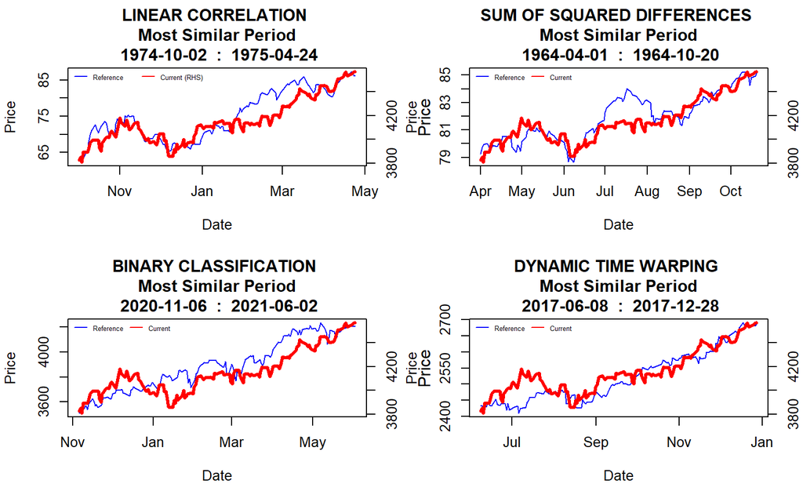

```r
par(mfrow=c(2,2))

# View Plot on Both Series
plot(as.zoo(reference[best.period.1:(best.period.1+w)]),lty = 1, col = c("blue"),xlab = "Date",ylab = "Price", main = paste("LINEAR CORRELATION \n Most Similar Period \n", index(reference_returns[best.period.1]), " : ", index(reference_returns[(best.period.1+w)])))
par(new =TRUE)
plot(as.zoo(current),screens = 1,lwd = 3, col = "red",xlab = "",ylab = "", xaxt = "n", yaxt = "n")
axis(4)
mtext("Price", side = 4, line = 3)
legend("topleft",c("Reference","Current (RHS)"),lty = c(1,1),col = c("blue","red"),cex = 0.5, bty = "n", horiz = T)

# View Plot on Both Series
plot(as.zoo(reference[best.period.2:(best.period.2+w)]),lty = 1, col = c("blue"), xlab = "Date", ylab = "Price", main = paste("SUM OF SQUARED DIFFERENCES \n Most Similar Period \n", index(reference_returns[best.period.2]), " : ", index(reference_returns[(best.period.2+w)])))
par(new =TRUE)
plot(as.zoo(current),screens = 1,lwd = 3, col = "red", xlab = "", ylab = "", xaxt = "n", yaxt = "n")
axis(4)
mtext("Price", side = 4, line = 3)
legend("topleft", c("Reference","Current"), lty = c(1,1), col = c("blue","red"), cex = 0.5, bty = "n", horiz = T)

# View Plot on Both Series
plot(as.zoo(reference[best.period.3:(best.period.3+w)]),lty = 1, col = c("blue"), xlab = "Date", ylab = "Price", main = paste("BINARY CLASSIFICATION \n Most Similar Period \n", index(reference_returns[best.period.3]), " : ", index(reference_returns[(best.period.3+w)])))
par(new =TRUE)
plot(as.zoo(current),screens = 1,lwd = 3, col = "red", xlab = "", ylab = "", xaxt = "n", yaxt = "n")
axis(4)
mtext("Price", side = 4, line = 3)
legend("topleft", c("Reference","Current"), lty = c(1,1), col = c("blue","red"), cex = 0.5, bty = "n", horiz = T)

# View Plot on Both Series
plot(as.zoo(reference[best.period.4:(best.period.4+w)]),lty = 1, col = c("blue"), xlab = "Date", ylab = "Price", main = paste("DYNAMIC TIME WARPING \n Most Similar Period \n", index(reference_returns[best.period.4]), " : ", index(reference_returns[(best.period.4+w)])))
par(new =TRUE)
plot(as.zoo(current),screens = 1,lwd = 3, col = "red", xlab = "", ylab = "", xaxt = "n", yaxt = "n")
axis(4)
mtext("Price", side = 4, line = 3)
legend("topleft", c("Reference","Current"), lty = c(1,1), col = c("blue","red"), cex = 0.5, bty = "n", horiz = T)
```

*Again, different definitions of similarity will yield different periods of association.*

## Future Paths

```r
par(mfrow=c(2,2))

future_GSPC_1 <- reference[(best.period.1+w):(best.period.1+(2*w))]
plot(future_GSPC_1)

future_GSPC_2 <- reference[(best.period.2+w):(best.period.2+(2*w))]
plot(future_GSPC_2)

future_GSPC_3 <- reference[(best.period.3+w):(best.period.3+(2*w))]
plot(future_GSPC_3)

future_GSPC_4 <- reference[(best.period.4+w):(best.period.4+(2*w))]
plot(future_GSPC_4)
```

[figure not shown]